# Implementing a Spam Filter with Bayesian Learning

## Taking a short detour on probability theory

In order to appreciate Bayes' theorem, we need to get a hold of the following technical terms:

- **Random variable:** This is a variable whose value depends on chance. A good example is the act of flipping a coin, which might turn up heads or tails. If a random variable can take on only a limited number of values, we call it **discrete** (such as a coin flip or a dice roll), otherwise we call it a **continuous** random variable (such as the temperature on a given day). Random variables are often typeset as capital letters.
- **Probability:** This is a measure of how likely it is for an event to occur. We denote the probability of an event $e$ happening as $p(e)$, which must be a number between 0 and 1 (or between 0 and 100%). For example, for the random variable $X$ denoting a coin toss, we can describe the probability of getting heads as $p(X = \text{heads}) = 0.5$ (if the coin is fair).
- **Conditional probability:** This is the measure of the probability of an event, given that another event has occurred. We denote the probability of event $y$ happening, given that we know event $x$ has already happened, as $p(y|x)$ (read *p of y given x*). For example, the probability of tomorrow being Tuesday if today is Monday is $p(\text{tomorrow will be Tuesday}|\text{today is Monday}) = 1$. Of course, there's also the chance that we won't see a tomorrow, but let's ignore that for now.
- **Probability distribution:** This is a function that tells you the probability of different events happening in an experiment. For discrete random variables, this function is also called the **probability mass function**. For continuous random variables, this function is also called the **probability density function**. For example, the probability distribution of the coin toss X would take the value 0.5 for $X = heads$, and 0.5 for $X = tails$. Across all possible outcomes, the distribution must add up to 1.
- **Joint probability distribution:** This is basically the preceding probability function applied to multiple random variables. For example, when flipping two fair coins $A$ and $B$, the joint probability distribution would enumerate all possible outcomes--($A = heads, B = heads$), ($A = heads, B = tails$), ($A = tails, B = heads$), and ($A = tails, B = tails$)--and tell you the probability of each of these outcomes.

Now here's the trick: If we think of a dataset as a random variable $X$, then a machine learning model is basically trying to learn the mapping of X onto a set of possible target labels $Y$. In other words, we are trying to learn the conditional probability $p(Y|X)$, which is the probability that a random sample drawn from $X$ has a target label $Y$.

There are two different ways to learn $p(Y|X)$, as briefly mentioned earlier:

1. Discriminative models: This class of models directly learns $p(Y|X)$ from training data without wasting any time trying to understand the underlying probability distributions (such as $p(X)$, $p(Y)$, or even $p(Y|X)$). This approach applies to pretty much every learning algorithm we have encountered so far: linear regression, *k*-nearest neighbors, decision trees, and so on.
2. Generative models: This class of model learns everything about the underlying probability distribution and then infers $p(Y|X)$ from the joint probability distribution $p(X, Y)$. Because these models know $p(X, Y)$, they can not only tell us how likely it is for a data point to have a particular target label but also generate entirely new data points. Bayesian models are one example of this class of models.

Cool, so how do Bayesian models actually work? Let's have a look at a specific example.

(...)

> *1% of women at age forty who participate in routine screening have breast cancer. 80% of women with breast cancer will get positive mammographies. 9.6% of women without breast cancer will also get positive mammographies. A woman in this age group had a positive mammography in a routine screening. What is the probability that she actually has breast cancer? What do you think the answer is?*

Si:

- $p(x)$ es la probabilidad de tener cáncer, y
- $p(y)$ es la probabilidad de dar positivo,

Para calcular $p(y)$ sabemos que:

- El 80% del 1% (población con cáncer) dará positivo, y
- El 9.6% del 99% (población sin cáncer) dará positivo también.

Entonces calculamos:

$$\begin{equation}\begin{array}{ll} p(y) &= \left(0.8 \cdot 0.01\right) + \left(0.096 \cdot 0.99\right) \\ &= (0.008) + (0.09504)\\ &= 0.10304 \end{array}\end{equation}$$

Con esto y los datos del problema vemos que:

$$\begin{equation} p(x) = 0.01 p(y|x) = 0.8 \\ p(y) = 0.10304 \end{equation}$$

El teorema es:

$$\begin{equation} p(A|B) = \frac{p(B|A) \; p(A)}{p(B)} \end{equation}$$

Donde:

- $p(A|B)$ es llamado el *posterior* (en inglés)
- $p(A)$ es el *prior*
- $p(B|A)$ es el *likelihood*
- $p(B)$ es la **evidencia**

Ergo,

$$\begin{equation}\begin{array}{ll} p(x|y) &= \frac{p(y|x) \; p(x)}{p(y)} \\ &= \frac{0.8 \cdot 0.01}{0.10304} \\ &= 0.077639... \approx 0.078 \end{array}\end{equation}$$

## Understanding the naive Bayes classifier

For a real world scenario with multiple pieces of evidence $X_1, X_2$ this would become:

$$ p(Y, X_1, X_2) = p(X_1|X_2, Y) \cdot p(X_2|C) \cdot p(C) $$

> Thus, the idea of the naive Bayes classifier is simply to ignore all those mixed terms and instead assume that all the pieces of evidence ($X_i$) are independent of each other. Since this is rarely the case in the real world, you might call this assumption a bit naive. And that's where the **naive** Bayes classifier got its name from.

Thus, it becomes:

$$\begin{equation} p(Y|X_1, X_2) = p(X_1|Y) \cdot p(X_2|Y) \cdot p(Y) \end{equation}$$

> The naive Bayes classifier then combines this model with a decision rule. The most common rule is to check all the equations (for all classes $Y_1, Y_2, ..., Y_m$) and then pick the class that has the highest probability. This is also known as the **maximum a posteriori (MAP)** decision rule.

## Implementation!

### Creating a toy dataset

```python
from sklearn import datasets
X, y = datasets.make_blobs(100, 2, centers=2,\
                          random_state=1701, cluster_std=2)
```

```python
import matplotlib.pyplot as plt
plt.style.use('ggplot')
%matplotlib inline
```

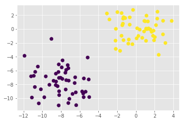

```python
plt.scatter(X[:, 0], X[:, 1], c=y, s=50);
```

```python
# we would expect this classification to be linear (easy)
# dividing the dataset, 10% are for testing
import numpy as np
from sklearn import model_selection as ms
X = X.astype(np.float32)
X_train, X_test, y_train, y_test = ms.train_test_split(\
    X, y, test_size=0.1)
```

```python
# OpenCV doesn't have naive Bayes classifier, only normal
# and expects data to be clustered into Gaussian blobs.

import cv2
model_norm = cv2.ml.NormalBayesClassifier_create()
```

```python
# training
model_norm.train(X_train, cv2.ml.ROW_SAMPLE, y_train)
# True
```

```
True
```

```python
# prediction, scoring
_, y_pred = model_norm.predict(X_test)
```

```python
from sklearn import metrics
metrics.accuracy_score(y_test, y_pred)
# 1.0
```

```
1.0
```

```python
# reusing plotting function to inspect the boundary

def plot_decision_boundary(model, X_test, y_test):
    # create a mesh to plot in
    h = 0.02 #step size
    x_min = X_test[:, 0].min() - 1
    x_max = X_test[:, 0].max() + 1
    y_min = X_test[:, 1].min() - 1
    y_max = X_test[:, 1].max() + 1
    xx, yy = np.meshgrid(np.arange(x_min, x_max, h),\
                        np.arange(y_min, y_max, h))
    #flatten into column with ravel, then stack again
    X_hypo = np.column_stack((xx.ravel().astype(np.float32),\
                             yy.ravel().astype(np.float32)))
    # X_hypo has all x values in the first axis and
    # all y values in the second one
    ret = model.predict(X_hypo)
    #Since we're using both opencv and scikit-learn, we have
    # to make them work together. Opencv returns a Boolean
    # flag and predicted target labels, and scikit only predictions
    # Thus, if 'ret' is a tuple, we're dealing with opencv
    if isinstance(ret, tuple):
        zz = ret[1]
    else:
        zz = ret
    zz = zz.reshape(xx.shape)
    # Contour plot
    plt.contourf(xx, yy, zz, cmap=plt.cm.coolwarm, alpha=0.8)
    plt.scatter(X_test[:, 0], X_test[:, 1], c=y_test, s=200)
```

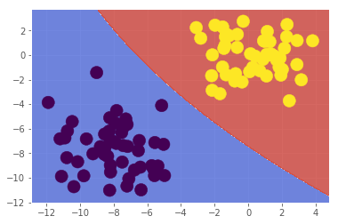

```python
# call the function with a model, a feature matrix and a
# target label vector

plot_decision_boundary(model_norm, X, y)
```

```python
# A Bayesian classifier also returns the probability with
# wich each data point has been classified
ret, y_pred, y_proba = model_norm.predictProb(X_test)
```

```python
# y_proba is a Nx2 matrix with probabilities for all
# N data points
y_proba.round(2)
```

```
array([[0.  , 0.1 ],
       [0.  , 0.13],
       [0.07, 0.  ],
       [0.  , 0.17],
       [0.  , 0.25],
       [0.17, 0.  ],
       [0.  , 0.16],
       [0.  , 0.2 ],
       [0.  , 0.21],
       [0.21, 0.  ]], dtype=float32)
```

# Classifying the data with a naive Bayes classifier

```python
from sklearn import naive_bayes
model_naive = naive_bayes.GaussianNB()
```

```python
# training via fit
model_naive.fit(X_train, y_train)
```

```
GaussianNB(priors=None)
```

```python
# scoring
model_naive.score(X_test, y_test)
```

```
1.0
```

```python
yprob = model_naive.predict_proba(X_test)
yprob.round(2)
```

```
array([[0., 1.],
       [0., 1.],
       [1., 0.],
       [0., 1.],
       [0., 1.],
       [1., 0.],
       [0., 1.],
       [0., 1.],
       [0., 1.],
       [1., 0.]])
```

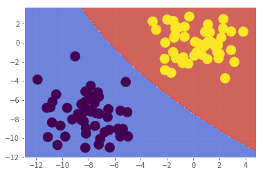

```python
plot_decision_boundary(model_naive, X, y)
```

# Visualizing conditional probs

```python
def plot_proba(model, X_test, y_test):
    # create a mesh to plot in
    h = 0.02
    x_min = X_test[:, 0].min() - 1
    x_max = X_test[:, 0].max() + 1
    y_min = X_test[:, 1].min() - 1
    y_max = X_test[:, 1].max() + 1
    xx, yy = np.meshgrid(np.arange(x_min, x_max, h),\
                        np.arange(y_min, y_max, h))
    X_hypo = np.column_stack((xx.ravel().astype(np.float32),\
                             yy.ravel().astype(np.float32)))
    # we need to implement a switch for predictProb in the
    # case of opencv and predict_proba for scikit-learn
    if hasattr(model, 'predictProb'):
        _, _, y_proba = model.predictProb(X_hypo)
    else:
        y_proba = model.predict_proba(X_hypo)
    zz = y_proba[:, 1] - y_proba[:, 0]
    zz = zz.reshape(xx.shape)
    # plotting
    plt.contourf(xx, yy, zz, cmap=plt.cm.coolwarm, alpha=0.8)
    plt.scatter(X_test[:, 0], X_test[:, 1], c=y_test, s=200)
```

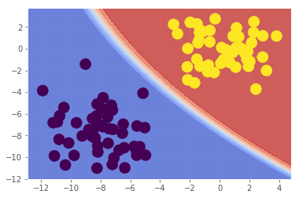

```python
plot_proba(model_naive, X, y)
```

## Referencias

- Beyeler, Michael. 2017. *Machine Learning for Opencv: Intelligent Image Processing with Python*. Vol. 1. Packt Publishing - ebooks Account.